← Voltar ao Portal

[figure not shown]

Programa 409

# Síntese Avaliativa do Desempenho dos Programas do PPA Bahia 2024–2027

# **1 - Desempenho Global do Programa**

Este documento apresenta uma Síntese Avaliativa do Desempenho do Programa do Plano Plurianual - PPA 2024- 2027, trazendo uma visão estratégica dos seus resultados, de forma sintética, transparente e colaborativa. Serão levados em consideração o Indicador Sintético de Desempenho do Programa (ISDP), a evolução dos Indicadores de Programa, a eficácia das metas dos Indicadores de Compromisso, o desempenho da execução orçamentária-financeira e da execução física das Ações orçamentárias. O ISDP é uma síntese dessas quatro dimensões, destacando o desempenho do programa em relação aos resultados obtidos e aos esforços despendidos.  
Adicionalmente, são apresentados os principais resultados alcançados, evidenciando os avanços e conformidades dos cinco programas com melhores resultados, além das oportunidades de melhoria dos cinco, com menores resultados. Enquanto neste documento a análise abrange o programa e seus componentes de maneira sintética, nos demais relatórios, a análise detalhada evidencia o comportamento dos componentes do PPA por programas e por órgãos (https://www.ba.gov.br/seplan/monitoramento-e-avaliacao/avaliacao-do-ppa). Além desta Síntese, o [Painel BI - Boletim de Avanços e Oportunidades de Melhoria](https://app.powerbi.com/view?r=eyJrIjoiN2Q0ODliNDItZDFjZi00MGM1LTliNGEtODVmZDAwZTQ1OGEyIiwidCI6IjRjZDgzNWY0LTU0NDAtNDA4Zi05M2EzLTk3NWZjMTdjMzg0YSIsImMiOjR9) oferece informações organizadas em uma perspectiva estratégica do desempenho consolidado dos programas, detalhando, no entanto, cada componente avaliado. A análise nesta seção engloba o programa e seus componentes conforme segue:

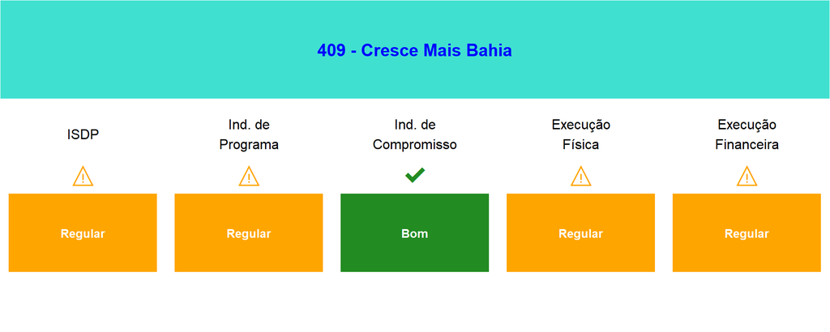

# **2 - Avanços e Conformidades no Programa**

**Indicadores de Programa:** No programa 409 - Cresce Mais Bahia, 60% dos indicadores também mostraram evolução positiva. Um dos destaques é o indicador 2254, que mede a proporção da massa salarial do interior em relação à massa salarial total da Bahia, apresentando uma evolução de 2,34%. No entanto, é importante ressaltar que esse indicador está prejudicado pelas mudanças nos registros da RAIS, que sofreram três alterações significativas entre 2019 e 2023, ocasionando “quebras de série”. Assim, a comparação do indicador deve ser retomada apenas a partir de 2023. O governo federal, por meio de notas técnicas, recomenda que a análise de séries históricas entre 2018 e 2022 considere essas variações artificiais. Destaca-se ainda o indicador 2256, que aponta uma variação percentual de 121,49% no estoque de empregos formais na indústria extrativa mineral. No entanto, os dados ainda são parciais, já que o ano de 2024 não pode ser contabilizado, uma vez que o Ministério do Trabalho e Emprego (MTE) publicou apenas informações parciais, e é necessário incluir os “serviços de apoio à mineração” na análise.  
**Indicadores de Compromisso:** No programa 409 - Cresce Mais Bahia, 61,6% dos indicadores de compromisso foram classificados como de desempenho bom ou ótimo. Um dos destaques é o indicador ‘4 - Percentual do valor de arrecadação da Central de Abastecimento - CEASA’, que atingiu 93,01%. Esse resultado está relacionado a fatores conjunturais, já que o desempenho ficou um pouco abaixo do esperado devido à oscilação na arrecadação, causada principalmente pela inadimplência dos permissionários. Outro indicador relevante é o ‘7 - Número de certificações realizadas no Centro Gemológico’, que alcançou 114,85%. Este resultado pode ser atribuído à otimização das estratégias de atuação, embora em 2024 tenha havido uma demanda inferior ao previsto, principalmente devido a problemas técnicos com a impressora que impossibilitaram a impressão de laudos por alguns meses. No entanto, em 2025, a aquisição de uma nova impressora permitiu atender a demanda de forma satisfatória, superando as expectativas.  
**Ações Orçamentárias:** Por fim, para o Programa 409 - Cresce Mais Bahia, a execução financeira mostrou que 29,3% das ações tiveram bom ou ótimo desempenho, enquanto 50% foram classificadas como de bom ou ótimo desempenho na execução física. Exemplos incluem a Ação 1807 - Realização de Estudo Geocientífico, que obteve execuções financeiras e físicas classificadas como Ótimas, e a Ação 1698 - Promoção de Oportunidade Mineral, que também se destacou em ambas as categorias.

# **3 - Oportunidade de Melhoria no Programa**

**Indicadores de Programa:** Entretanto, no Programa 409 - Cresce Mais Bahia, 40% dos indicadores apresentaram evolução negativa, destacando-se o indicador 2258, que mede o Índice do Valor Adicionado da Indústria Extrativa Mineral, que registrou uma diminuição de 17,69%. Isso reflete uma tendência observada em 2023, onde a extração de petróleo e gás natural sofreu impacto causado por crises globais e pela desaceleração da economia, resultando em um declínio na produção mineral comercializada na Bahia.  
**Indicadores de Compromisso:** No programa 409 - Cresce Mais Bahia, a avaliação revelou que 23,1% dos indicadores foram considerados de baixo desempenho, com 15,4% indeterminados. O indicador sobre ‘Número de áreas industriais requalificadas’ obteve 0% devido a serviços ainda em andamento e problemas ambientais que atrasaram o processo. As requalificações seguem em curso, mas com desafios que precisam ser superados para a conclusão das metas.  
**Ações Orçamentárias:** No entanto, no Programa 409 - Cresce Mais Bahia, 48,8% das ações foram avaliadas como de baixo ou muito baixo desempenho na execução financeira, e 45,5% na execução física. Exemplos disso são a ação 5102 - Apoio à Implantação de Unidade de Produção Mineral e a ação 5008 - Requalificação de Área Industrial em Ilhéus, que apresentaram baixos desempenhos em ambas as áreas.

Desenvolvido por: DAP – Diretoria de Avaliação de Políticas Públicas